# A cool title

Szenes, Daniel and del Perugia, Louis

01 December, 2020

# 1 Introduction

- Overview and Motivation

The objective of this project is to overview the crime situation in a city. We will focus our attention on San Francisco, which is a city known for its cultural richness as well as its economic strength. Starting from the media observation that our society is only increasing its violence, we will begin by determining if the dangerousness of crime has increased over time, in a period of 20 years. To explain these changes, we will focus on the evolution of certain demographic variables (population density, income, poverty, unemployment rate, ethnicity of the population and education) specific to the different neighborhoods of San Francisco. Considering that criminals travel, we will also determine whether public transportation density is correlated with crime. Finally, we will focus on the societal change created by the lockdown of COVID19 that might be transferred to crime. One member of the group took a criminology course during his bachelor’s degree and was deeply interested in explaining the crime. Seeking to understand the why of crime is really research that could be useful for other studies and there is still a lot to be discovered. We also wanted to follow how the criminal world reacted to the current event affecting the world.

- Related Work

We were very interested in the presentation of the assistant Ilia Azizi during the course. Working with geospatial visualization was a deep passion for us and we took working with geospatial data as a challenge.

- The research questions we will attempt to answer with this project are:
1. **Has the seriousness of crimes increased/decreased over the last 20 year? Does the change in education, income, ethnicity of the population, poverty, unemployment rate, population density can explain this change?**
2. **Given the organization of public transport in the city, can we say that the places with the most crime are those that are the most connected by transport?**
3. **Does the COVID change tendencies concerning criminality in San Francisco?**

# 2 Data

## 2.1 Crime Data

First, we will load two data sets that record the incident reports that have been filed to the police.

### 2.1.1 2018 To Present

```
#> tibble [403,512 x 36] (S3: tbl_df/tbl/data.frame)
#>  $ Incident Datetime                                   : chr [1:40"..
#>  $ Incident Date                                       : Date[1:40"..
#>  $ Incident Time                                       : 'hms' num ..
#>   ..- attr(*, "units")= chr "secs"
#>  $ Incident Year                                       : num [1:403..
#>  $ Incident Day of Week                                : chr [1:40"..
#>  $ Report Datetime                                     : chr [1:40"..
#>  $ Row ID                                              : num [1:403..
#>  $ Incident ID                                         : num [1:403..
#>  $ Incident Number                                     : num [1:403..
#>  $ CAD Number                                          : num [1:403..
#>  $ Report Type Code                                    : chr [1:40"..
#>  $ Report Type Description                             : chr [1:40"..
#>  $ Filed Online                                        : logi [1:40..
#>  $ Incident Code                                       : chr [1:40"..
#>  $ Incident Category                                   : chr [1:40"..
#>  $ Incident Subcategory                                : chr [1:40"..
#>  $ Incident Description                                : chr [1:40"..
#>  $ Resolution                                          : chr [1:40"..
#>  $ Intersection                                        : chr [1:40"..
#>  $ CNN                                                 : num [1:403..
#>  $ Police District                                     : chr [1:40"..
#>  $ Analysis Neighborhood                               : chr [1:40"..
#>  $ Supervisor District                                 : num [1:403..
#>  $ Latitude                                            : num [1:403..
#>  $ Longitude                                           : num [1:403..
#>  $ point                                               : chr [1:40"..
#>  $ SF Find Neighborhoods                               : num [1:403..
#>  $ Current Police Districts                            : num [1:403..
#>  $ Current Supervisor Districts                        : num [1:403..
#>  $ Analysis Neighborhoods                              : num [1:403..
#>  $ HSOC Zones as of 2018-06-05                         : num [1:403..
#>  $ OWED Public Spaces                                  : num [1:403..
#>  $ Central Market/Tenderloin Boundary Polygon - Updated: num [1:403..
#>  $ Parks Alliance CPSI (27+TL sites)                   : num [1:403..
#>  $ ESNCAG - Boundary File                              : num [1:403..
#>  $ Areas of Vulnerability, 2016                        : num [1:403..
#>  - attr(*, "spec")=
#>   .. cols(
```

[output cut: 22 more lines]

```
#>   ..   `Supervisor District` = col_double(),
#>   ..   Latitude = col_double(),
#>   ..   Longitude = col_double(),
#>   ..   point = col_character(),
#>   ..   `SF Find Neighborhoods` = col_double(),
#>   ..   `Current Police Districts` = col_double(),
#>   ..   `Current Supervisor Districts` = col_double(),
#>   ..   `Analysis Neighborhoods` = col_double(),
#>   ..   `HSOC Zones as of 2018-06-05` = col_double(),
#>   ..   `OWED Public Spaces` = col_double(),
#>   ..   `Central Market/Tenderloin Boundary Polygon - Updated` = col..
#>   ..   `Parks Alliance CPSI (27+TL sites)` = col_double(),
#>   ..   `ESNCAG - Boundary File` = col_double(),
#>   ..   `Areas of Vulnerability, 2016` = col_double()
#>   .. )
```

Source of the data set: [https://data.sfgov.org/Public-Safety/Police-Department-Incident-Reports-2018-to-Present/wg3w-h783]

- Column of the data set:
  - `Incident Datetime` The date and time when the incident occurred
  - `Incident Date` The date the incident occurred
  - `Incident Time` The date the incident occurred
  - `Incident Year` The year the incident occurred, provided as a convenience for filtering
  - `Incident Day of Week`The day of week the incident occurred
  - `Report Datetime` Distinct from Incident Datetime, Report Datetime is when the report was filed.
  - `Row ID` A unique identifier for each row of data in the dataset
  - `Incident ID` This is the system generated identifier for incident reports. Incident IDs and Incident Numbers both uniquely identify reports, but Incident Numbers are used when referencing cases and report documents.
  - `Incident Number` The number issued on the report, sometimes interchangeably referred to as the Case Number. This number is used to reference cases and report documents.
  - `CAD Number` The Computer Aided Dispatch (CAD) is the system used by the Department of Emergency Management (DEM) to dispatch officers and other public safety personnel.
  - `Report Type Code`A system code for report types, these have corresponding descriptions within the dataset.
  - `Report Type Description` The description of the report type, can be one of: Initial; Initial Supplement; Vehicle Initial; Vehicle Supplement; Coplogic Initial; Coplogic Supplement
  - `Filed Online` Non- emergency police reports can be filed online by members of the public using SFPD’s self-service reporting system called Coplogic Values in this field will be “TRUE” if Coplogic was used to file the report. Please reference the link below for additional info
  - `Incident Code` Incident Codes are the system codes to describe a type of incident. A single incident report can have one or more incident types associated.
  - `Incident Category` A category mapped on to the Incident Code used in statistics and reporting.
  - `Incident Subcategory` A subcategory mapped to the Incident Code that is used for statistics and reporting.
  - `Incident Description` The description of the incident that corresponds with the Incident Code.
  - `Resolution` The resolution of the incident at the time of the report.
  - `Intersection` The 2 or more street names that intersect closest to the original incident separated by a backward slash
  - `CNN` The unique identifier of the intersection for reference back to other related basemap datasets.
  - `Police District` The Police District where the incident occurred. District boundaries can be reviewed in the link below [https://data.sfgov.org/d/wkhw-cjsf]. Please note this field is entered by officers and not based on the point.
  - `Analysis Neighborhood` This field is used to identify the neighborhood where each incident occurs. Neighborhoods and boundaries are defined by the Department of Public Health and the Mayor’s Office of Housing and Community Development. Please reference the link below for additional info: [https://data.sfgov.org/d/p5b7-5n3h].
  - `Supervisor District` There are 11 members elected to the Board of Supervisors in San Francisco, each representing a geographic district. The Board of Supervisors is the legislative body for San Francisco. The districts are numbered 1 through 11. Please reference the link below for additional info: [https://data.sfgov.org/d/8nkz-x4ny].
  - `Latitude` The latitude coordinate
  - `Longitude` The longitude coordinate
  - `point` The point geometry used for mapping features in the open data portal platform. Latitude and Longitude are provided separately as well as a convenience.

In order to be able to join the two datasets that have a different temporality and thus focus on variables to answer the chosen research questions, we have removed a few columns.

- We will focus on these variables:`Incident Date`, `Incident Time`, `Incident Day of Week`, `Incident Category`, `Resolution`, `Analysis Neighborhood`, `point`.

This information will be useful to us in order to look at the evolution of crime over time and also to analyze crime by neighborhood and thus be able to analyze whether this variation in crime across neighborhoods can be explained by socio-economic variables.

### 2.1.2 2003 To 2018

```
#> tibble [2,160,953 x 35] (S3: tbl_df/tbl/data.frame)
#>  $ PdId                                                    : num [1..
#>  $ IncidntNum                                              : chr ["..
#>  $ Incident Code                                           : chr ["..
#>  $ Category                                                : chr ["..
#>  $ Descript                                                : chr ["..
#>  $ DayOfWeek                                               : chr ["..
#>  $ Date                                                    : chr ["..
#>  $ Time                                                    : 'hms' ..
#>   ..- attr(*, "units")= chr "secs"
#>  $ PdDistrict                                              : chr ["..
#>  $ Resolution                                              : chr ["..
#>  $ Address                                                 : chr ["..
#>  $ X                                                       : num [1..
#>  $ Y                                                       : num [1..
#>  $ location                                                : chr ["..
#>  $ SF Find Neighborhoods 2 2                               : num [1..
#>  $ Current Police Districts 2 2                            : num [1..
#>  $ Current Supervisor Districts 2 2                        : num [1..
#>  $ Analysis Neighborhoods 2 2                              : num [1..
#>  $ DELETE - Fire Prevention Districts 2 2                  : num [1..
#>  $ DELETE - Police Districts 2 2                           : num [1..
#>  $ DELETE - Supervisor Districts 2 2                       : num [1..
#>  $ DELETE - Zip Codes 2 2                                  : num [1..
#>  $ DELETE - Neighborhoods 2 2                              : num [1..
#>  $ DELETE - 2017 Fix It Zones 2 2                          : num [1..
#>  $ Civic Center Harm Reduction Project Boundary 2 2        : num [1..
#>  $ Fix It Zones as of 2017-11-06  2 2                      : num [1..
#>  $ DELETE - HSOC Zones 2 2                                 : num [1..
#>  $ Fix It Zones as of 2018-02-07 2 2                       : num [1..
#>  $ CBD, BID and GBD Boundaries as of 2017 2 2              : num [1..
#>  $ Areas of Vulnerability, 2016 2 2                        : num [1..
#>  $ Central Market/Tenderloin Boundary 2 2                  : num [1..
#>  $ Central Market/Tenderloin Boundary Polygon - Updated 2 2: num [1..
#>  $ HSOC Zones as of 2018-06-05 2 2                         : num [1..
#>  $ OWED Public Spaces 2 2                                  : num [1..
#>  $ Neighborhoods 2                                         : num [1..
#>  - attr(*, "spec")=
#>   .. cols(
#>   ..   PdId = col_double(),
```

[output cut: 20 more lines]

```
#>   ..   `DELETE - Zip Codes 2 2` = col_double(),
#>   ..   `DELETE - Neighborhoods 2 2` = col_double(),
#>   ..   `DELETE - 2017 Fix It Zones 2 2` = col_double(),
#>   ..   `Civic Center Harm Reduction Project Boundary 2 2` = col_dou..
#>   ..   `Fix It Zones as of 2017-11-06  2 2` = col_double(),
#>   ..   `DELETE - HSOC Zones 2 2` = col_double(),
#>   ..   `Fix It Zones as of 2018-02-07 2 2` = col_double(),
#>   ..   `CBD, BID and GBD Boundaries as of 2017 2 2` = col_double(),
#>   ..   `Areas of Vulnerability, 2016 2 2` = col_double(),
#>   ..   `Central Market/Tenderloin Boundary 2 2` = col_double(),
#>   ..   `Central Market/Tenderloin Boundary Polygon - Updated 2 2` =..
#>   ..   `HSOC Zones as of 2018-06-05 2 2` = col_double(),
#>   ..   `OWED Public Spaces 2 2` = col_double(),
#>   ..   `Neighborhoods 2` = col_double()
#>   .. )
```

Source of the data set: [https://data.sfgov.org/Public-Safety/Police-Department-Incident-Reports-Historical-2003/tmnf-yvry]

This dataset covers the period from the 1st January 2003 to the 15th May 2018 and contains about 2.16M observations.

- Column of the data set:
  - `PdId` A unique identifier for each row of data in the dataset
  - `IncidntNum` The number issued on the report, sometimes interchangeably referred to as the Case Number. This number is used to reference cases and report documents.
  - `Incident Code` Incident Codes are the system codes to describe a type of incident. A single incident report can have one or more incident types associated.
  - `Incident Category` A category mapped on to the Incident Code used in statistics and reporting.
  - `Descript` The description of the incident that corresponds with the Incident Code.
  - `DayOfWeek` The day of week the incident occurred
  - `Date` The date the incident occurred
  - `Time` The date the incident occurred
  - `PdDistrict` The Police District where the incident occurred. District boundaries can be reviewed in the link below. Please note this field is entered by officers and not based on the point. Reference here: [https://data.sfgov.org/d/wkhw-cjsf].
  - `Resolution` The resolution of the incident at the time of the report.
  - `Address` The 2 or more street names that intersect closest to the original incident separated by a backward slash
  - `Y` The latitude coordinate
  - `X` The longitude coordinate
  - `location` The point geometry used for mapping features in the open data portal platform. Latitude and Longitude are provided separately as well as a convenience.
  - `Analysis Neighborhoods 2 2` This field is used to identify the neighborhood where each incident occurs. Neighborhoods and boundaries are defined by the Department of Public Health and the Mayor’s Office of Housing and Community Development. Please reference the link below for additional info: [https://data.sfgov.org/d/p5b7-5n3h].
- As for the 3.1.1 data set, we will focus on these variables:`Incident Category`, `DayOfWeek`, `DayOfWeek`, `Date`, `Time`, `Resolution`, `Y`, `X`, `location`,`Analysis Neighborhoods 2 2`.

For the `Analysis Neighborhoods 2 2`, we had to see if the neighbourhood numbers corresponded to an alphabetical ranking of the neighbourhoods. It was absolutely not the case and we had to look for each number, which was the corresponding neighborhood. All this in order to join the two data sets.

## 2.2 Socio-Economic Data

### 2.2.1 2012 To 2016

Then, we will load four data sets that record the evolution of some socio-economic variables for each neighborhood of San Francisco. As these reports - built with census data - were only exported in pdf format, we decided to create our own data set in csv in order to use the information from these reports for different periods.

```
#> tibble [48 x 39] (S3: tbl_df/tbl/data.frame)
#>  $ NEIGHBORHOOD                    : chr [1:48] "Bayview Hunters P"..
#>  $ Time Horizon                    : chr [1:48] "2012-2016" "2012-"..
#>  $ Total Population                : num [1:48] 37600 26140 21090 1..
#>  $ Households                      : num [1:48] 11310 9120 11160 68..
#>  $ Family Households               : num [1:48] 0.72 0.57 0.29 0.52..
#>  $ Non-Family Households           : num [1:48] 0.28 0.43 0.71 0.48..
#>  $ Average Household Size          : num [1:48] 3.3 2.8 1.9 2.2 3.5..
#>  $ Asian                           : num [1:48] 0.36 0.17 0.12 0.81..
#>  $ Black/African American          : num [1:48] 0.28 0.05 0.03 0.01..
#>  $ White                           : num [1:48] 0.14 0.57 0.78 0.14..
#>  $ Native American Indian          : num [1:48] 0.003 0.01 0.004 0...
#>  $ Native Hawaiian/Pacific Islander: num [1:48] 0.02 0.001 0.004 NA..
#>  $ Other/Two or More Races         : num [1:48] 0.19 0.21 0.07 0.04..
#>  $ Latino (of Any Race)            : num [1:48] 0.22 0.29 0.08 0.04..
#>  $ 0-4 years                       : num [1:48] 0.07 0.07 0.04 0.03..
#>  $ 5-17 years                      : num [1:48] 0.18 0.11 0.05 0.09..
#>  $ 18-34 years                     : num [1:48] 0.25 0.25 0.29 0.22..
#>  $ 35-59 years                     : num [1:48] 0.33 0.41 0.46 0.31..
#>  $ 60 and older                    : num [1:48] 0.17 0.17 0.17 0.35..
#>  $ Median Age                      : num [1:48] 35 39.1 41.4 50.4 4..
#>  $ High School or Less             : num [1:48] 0.49 0.24 0.08 0.69..
#>  $ Some College/Associate Degree   : num [1:48] 0.26 0.22 0.17 0.12..
#>  $ College Degree                  : num [1:48] 0.18 0.31 0.37 0.16..
#>  $ Graduate/Professional Degree    : num [1:48] 0.07 0.22 0.38 0.03..
#>  $ Foreign Born                    : num [1:48] 0.39 0.29 0.19 0.71..
#>  $ English Only                    : num [1:48] 0.45 0.61 0.8 0.19 ..
#>  $ Spanish Only                    : num [1:48] 0.18 0.23 0.05 0.03..
#>  $ Asian/Pacific Islander          : num [1:48] 0.35 0.1 0.05 0.75 ..
#>  $ Other European Languages        : num [1:48] 0.02 0.05 0.08 0.02..
#>  $ Other Languages                 : num [1:48] 0.01 0.01 0.02 0 0...
#>  $ Units of Housing                : num [1:48] 12040 9770 12200 74..
#>  $ Median Year Structure Build     : num [1:48] 1962 1949 1956 1957..
#>  $ Median Rent                     : num [1:48] 1083 1252 1216 558 ..
#>  $ Median Home Value               : num [1:48] 566355 838307 90720..
#>  $ Vehicles Available              : num [1:48] 16810 12530 11220 1..
#>  $ Median Household Income         : num [1:48] 55750 106914 127273..
#>  $ Percent in Poverty              : num [1:48] 0.19 0.09 0.07 0.27..
#>  $ Unemployment Rate               : num [1:48] 0.12 0.07 0.04 0.07..
#>  $ Population Density per Acre     : num [1:48] 11.4 37.9 38.4 103...
```

[output cut: 27 more lines]

```
#>   ..   `English Only` = col_double(),
#>   ..   `Spanish Only` = col_double(),
#>   ..   `Asian/Pacific Islander` = col_double(),
#>   ..   `Other European Languages` = col_double(),
#>   ..   `Other Languages` = col_double(),
#>   ..   `Units of Housing` = col_double(),
#>   ..   `Median Year Structure Build` = col_double(),
#>   ..   `Median Rent` = col_double(),
#>   ..   `Median Home Value` = col_double(),
#>   ..   `Vehicles Available` = col_double(),
#>   ..   `Median Household Income` = col_double(),
#>   ..   `Percent in Poverty` = col_double(),
#>   ..   `Unemployment Rate` = col_double(),
#>   ..   `Population Density per Acre` = col_double()
#>   .. )
```

Source of the data set: [https://default.sfplanning.org/publications_reports/SF_NGBD_SocioEconomic_Profiles/2012-2016_ACS_Profile_Neighborhoods_Final.pdf]

### 2.2.2 2010 To 2014

```
#> Warning: Missing column names filled in: 'X39' [39]
#> tibble [42 x 40] (S3: tbl_df/tbl/data.frame)
#>  $ NEIGHBORHOOD                    : chr [1:42] "Bayview Hunters P"..
#>  $ Time Horizon                    : chr [1:42] "2010-2014" "2010-"..
#>  $ Total Population                : num [1:42] 37500 25840 20260 1..
#>  $ Households                      : num [1:42] 10960 9160 11070 66..
#>  $ Family Households               : num [1:42] 0.73 0.57 0.24 0.52..
#>  $ Non-Family Households           : num [1:42] 0.27 0.43 0.76 0.48..
#>  $ Average Household Size          : num [1:42] 3.4 2.8 1.8 2.2 3.6..
#>  $ Asian                           : num [1:42] 0.34 0.16 0.09 0.8 ..
#>  $ Black/African American          : num [1:42] 0.31 0.06 0.03 0.02..
#>  $ White                           : num [1:42] 0.17 0.56 0.004 0.1..
#>  $ Native American Indian          : num [1:42] 0.01 0.03 0.01 0.00..
#>  $ Native Hawaiian/Pacific Islander: num [1:42] 0.02 0.005 0.004 0 ..
#>  $ Other/Two or More Races         : num [1:42] 0.15 0.19 0.07 0.03..
#>  $ Latino (of Any Race)            : num [1:42] 0.22 0.33 0.1 0.03 ..
#>  $ 0-4 years                       : num [1:42] 0.08 0.06 0.06 0.02..
#>  $ 5-17 years                      : num [1:42] 0.17 0.12 0.12 0.1 ..
#>  $ 18-34 years                     : num [1:42] 0.25 0.27 0.27 0.21..
#>  $ 35-59 years                     : num [1:42] 0.33 0.4 0.4 0.32 0..
#>  $ 60 and older                    : num [1:42] 0.17 0.16 0.16 0.35..
#>  $ Median Age                      : num [1:42] 34.6 37.8 37.8 50.4..
#>  $ High School or Less             : num [1:42] 0.5 0.25 0.25 0.7 0..
#>  $ Some College/Associate Degree   : num [1:42] 0.28 0.22 0.22 0.1 ..
#>  $ College Degree                  : num [1:42] 0.17 0.31 0.31 0.17..
#>  $ Graduate/Professional Degree    : num [1:42] 0.06 0.21 0.21 0.03..
#>  $ Foreign Born                    : num [1:42] 0.38 0.29 0.29 0.7 ..
#>  $ English Only                    : num [1:42] 0.46 0.6 0.6 0.2 0...
#>  $ Spanish Only                    : num [1:42] 0.18 0.26 0.26 0.03..
#>  $ Asian/Pacific Islander          : num [1:42] 0.35 0.09 0.09 0.76..
#>  $ Other European Languages        : num [1:42] 0.01 0.04 0.04 0.02..
#>  $ Other Languages                 : num [1:42] 0.01 0.01 0.01 0 0...
#>  $ Units of Housing                : num [1:42] 11920 9800 9800 735..
#>  $ Median Year Structure Build     : num [1:42] 1957 1934 1934 1899..
#>  $ Median Rent                     : num [1:42] 1820 2000 2000 570 ..
#>  $ Median Home Value               : num [1:42] 476820 788530 78853..
#>  $ Vehicles Available              : num [1:42] 16180 12500 12500 1..
#>  $ Median Household Income         : num [1:42] 51450 92550 92550 1..
#>  $ Percent in Poverty              : num [1:42] 0.22 0.09 0.09 0.28..
#>  $ Unemployment Rate               : num [1:42] 0.14 0.1 0.1 0.1 0...
```

[output cut: 30 more lines]

```
#>   ..   `Spanish Only` = col_double(),
#>   ..   `Asian/Pacific Islander` = col_double(),
#>   ..   `Other European Languages` = col_double(),
#>   ..   `Other Languages` = col_double(),
#>   ..   `Units of Housing` = col_double(),
#>   ..   `Median Year Structure Build` = col_double(),
#>   ..   `Median Rent` = col_double(),
#>   ..   `Median Home Value` = col_double(),
#>   ..   `Vehicles Available` = col_double(),
#>   ..   `Median Household Income` = col_double(),
#>   ..   `Percent in Poverty` = col_double(),
#>   ..   `Unemployment Rate` = col_double(),
#>   ..   X39 = col_logical(),
#>   ..   `Population Density per Acre` = col_logical()
#>   .. )
```

### 2.2.3 2011 To 2015

```
#> tibble [42 x 39] (S3: tbl_df/tbl/data.frame)
#>  $ NEIGHBORHOOD                    : chr [1:42] "Bayview Hunters P"..
#>  $ Time Horizon                    : chr [1:42] "2011-2015" "2011-"..
#>  $ Total Population                : num [1:42] 37250 25490 20380 1..
#>  $ Households                      : num [1:42] 11180 9200 11020 66..
#>  $ Family Households               : num [1:42] 0.72 0.56 0.26 0.5 ..
#>  $ Non-Family Households           : num [1:42] 0.28 0.44 0.74 0.5 ..
#>  $ Average Household Size          : num [1:42] 3.3 2.7 1.8 2.1 3.6..
#>  $ Asian                           : num [1:42] 0.36 0.16 0.11 0.81..
#>  $ Black/African American          : num [1:42] 0.28 0.05 0.03 0.01..
#>  $ White                           : num [1:42] 0.17 0.59 0.79 0.15..
#>  $ Native American Indian          : num [1:42] 0.004 0.04 0.005 0...
#>  $ Native Hawaiian/Pacific Islander: num [1:42] 0.03 0 0 0 0 0 0 0 ..
#>  $ Other/Two or More Races         : num [1:42] 0.17 0.19 0.06 0.03..
#>  $ Latino (of Any Race)            : num [1:42] 0.22 0.29 0.1 0.04 ..
#>  $ 0-4 years                       : num [1:42] 0.07 0.07 0.03 0.02..
#>  $ 5-17 years                      : num [1:42] 0.19 0.11 0.05 0.09..
#>  $ 18-34 years                     : num [1:42] 0.25 0.25 0.27 0.22..
#>  $ 35-59 years                     : num [1:42] 0.34 0.45 0.48 0.31..
#>  $ 60 and older                    : num [1:42] 0.16 0.16 0.18 0.36..
#>  $ Median Age                      : num [1:42] 34.8 38.3 42.5 50.7..
#>  $ High School or Less             : num [1:42] 0.5 0.23 0.08 0.7 0..
#>  $ Some College/Associate Degree   : num [1:42] 0.26 0.28 0.16 0.11..
#>  $ College Degree                  : num [1:42] 0.17 0.32 0.38 0.16..
#>  $ Graduate/Professional Degree    : num [1:42] 0.07 0.23 0.38 0.03..
#>  $ Foreign Born                    : num [1:42] 0.38 0.28 0.19 0.72..
#>  $ English Only                    : num [1:42] 0.45 0.63 0.81 0.2 ..
#>  $ Spanish Only                    : num [1:42] 0.18 0.22 0.06 0.02..
#>  $ Asian/Pacific Islander          : num [1:42] 0.34 0.1 0.05 0.76 ..
#>  $ Other European Languages        : num [1:42] 0.02 0.04 0.07 0.02..
#>  $ Other Languages                 : num [1:42] 0.01 0.01 0.01 0 0...
#>  $ Units of Housing                : num [1:42] 12020 9810 12160 73..
#>  $ Median Year Structure Build     : num [1:42] 1963 1953 1956 1955..
#>  $ Median Rent                     : num [1:42] 990 2070 1410 570 1..
#>  $ Median Home Value               : num [1:42] 507180 799500 87752..
#>  $ Vehicles Available              : num [1:42] 16560 12430 11190 1..
#>  $ Median Household Income         : num [1:42] 52430 98270 120650 ..
#>  $ Percent in Poverty              : num [1:42] 0.22 0.09 0.07 0.3 ..
#>  $ Unemployment Rate               : num [1:42] 0.12 0.08 0.04 0.09..
#>  $ Population Density per Acre     : num [1:42] 11.3 36.9 37.1 99.7..
```

[output cut: 27 more lines]

```
#>   ..   `English Only` = col_double(),
#>   ..   `Spanish Only` = col_double(),
#>   ..   `Asian/Pacific Islander` = col_double(),
#>   ..   `Other European Languages` = col_double(),
#>   ..   `Other Languages` = col_double(),
#>   ..   `Units of Housing` = col_double(),
#>   ..   `Median Year Structure Build` = col_double(),
#>   ..   `Median Rent` = col_double(),
#>   ..   `Median Home Value` = col_double(),
#>   ..   `Vehicles Available` = col_double(),
#>   ..   `Median Household Income` = col_double(),
#>   ..   `Percent in Poverty` = col_double(),
#>   ..   `Unemployment Rate` = col_double(),
#>   ..   `Population Density per Acre` = col_double()
#>   .. )
```

### 2.2.4 2005 To 2009

```
#> tibble [42 x 39] (S3: tbl_df/tbl/data.frame)
#>  $ NEIGHBORHOOD                    : chr [1:42] "Bayview Hunters P"..
#>  $ Time Horizon                    : chr [1:42] "2005-2009" "2005-"..
#>  $ Total Population                : num [1:42] 35890 23390 19790 1..
#>  $ Households                      : num [1:42] 9480 9170 13810 672..
#>  $ Family Households               : num [1:42] 0.7 0.51 0.23 0.48 ..
#>  $ Non-Family Households           : num [1:42] 0.3 0.49 0.77 0.52 ..
#>  $ Average Household Size          : num [1:42] 3.6 2.8 1.9 2.1 3.7..
#>  $ Asian                           : num [1:42] 0.33 0.16 0.1 0.84 ..
#>  $ Black/African American          : num [1:42] 0.32 0.05 0.02 0.02..
#>  $ White                           : num [1:42] 0.12 0.59 0.8 0.12 ..
#>  $ Native American Indian          : num [1:42] 0.01 0.01 0 0 0.01 ..
#>  $ Native Hawaiian/Pacific Islander: num [1:42] 0.03 0 0 0 0 0 0 NA..
#>  $ Other/Two or More Races         : num [1:42] 0.2 0.19 0.08 0.02 ..
#>  $ Latino (of Any Race)            : num [1:42] 0.25 0.29 0.08 0.02..
#>  $ 0-4 years                       : num [1:42] 0.08 0.07 0.04 0.03..
#>  $ 5-17 years                      : num [1:42] 0.19 0.1 0.03 0.08 ..
#>  $ 18-34 years                     : num [1:42] 0.26 0.26 0.26 0.19..
#>  $ 35-59 years                     : num [1:42] 0.32 0.44 0.53 0.31..
#>  $ 60 and older                    : num [1:42] 0.16 0.14 0.14 0.39..
#>  $ Median Age                      : logi [1:42] NA NA NA NA NA NA ..
#>  $ High School or Less             : num [1:42] 0.56 0.28 0.1 0.7 0..
#>  $ Some College/Associate Degree   : num [1:42] 0.26 0.21 0.19 0.13..
#>  $ College Degree                  : num [1:42] 0.13 0.3 0.43 0.12 ..
#>  $ Graduate/Professional Degree    : num [1:42] 0.04 0.21 0.28 0.04..
#>  $ Foreign Born                    : num [1:42] 0.33 0.28 0.16 0.75..
#>  $ English Only                    : num [1:42] 0.51 0.58 0.79 0.12..
#>  $ Spanish Only                    : num [1:42] 0.21 0.27 0.07 0.01..
#>  $ Asian/Pacific Islander          : num [1:42] 0.27 0.11 0.05 0.84..
#>  $ Other European Languages        : num [1:42] 0.01 0.04 0.08 0.01..
#>  $ Other Languages                 : num [1:42] 0.01 0 0.01 0 0.01 ..
#>  $ Units of Housing                : num [1:42] 10540 9710 14810 74..
#>  $ Median Year Structure Build     : num [1:42] 1952 1939 1939 1939..
#>  $ Median Rent                     : num [1:42] 768 1373 1485 478 1..
#>  $ Median Home Value               : num [1:42] 586201 747500 94624..
#>  $ Vehicles Available              : num [1:42] 12760 12520 14890 1..
#>  $ Median Household Income         : num [1:42] 43155 85607 92237 1..
#>  $ Percent in Poverty              : num [1:42] 0.18 0.09 0.08 0.31..
#>  $ Unemployment Rate               : num [1:42] 0.14 0.06 0.05 0.15..
#>  $ Population Density per Acre     : logi [1:42] NA NA NA NA NA NA ..
```

[output cut: 27 more lines]

```
#>   ..   `English Only` = col_double(),
#>   ..   `Spanish Only` = col_double(),
#>   ..   `Asian/Pacific Islander` = col_double(),
#>   ..   `Other European Languages` = col_double(),
#>   ..   `Other Languages` = col_double(),
#>   ..   `Units of Housing` = col_double(),
#>   ..   `Median Year Structure Build` = col_double(),
#>   ..   `Median Rent` = col_double(),
#>   ..   `Median Home Value` = col_double(),
#>   ..   `Vehicles Available` = col_double(),
#>   ..   `Median Household Income` = col_double(),
#>   ..   `Percent in Poverty` = col_double(),
#>   ..   `Unemployment Rate` = col_double(),
#>   ..   `Population Density per Acre` = col_logical()
#>   .. )
```

Source of the data set: [https://sf-planning.org/sites/default/files/FileCenter/Documents/8501-SFProfilesByNeighborhoodForWeb.pdf]

- Column of the data sets:
  - `NEIGHBOORHOD` Each neighborhood of San Franciso. Segmented using the geospatial data in this link : [https://data.sfgov.org/Geographic-Locations-and-Boundaries/Analysis-Neighborhoods/p5b7-5n3h]
  - `Time Horizon` This column highlights the time horizon where the data have been collected.
  - `Total Population` This column highlights the total population for each neighbourhood.
  - `Households` This column highlights the total households number for each neighbourhood.
  - `Family Households` This column highlights the proportion of family-households within a neighborhood.
  - `Non-Family Households` This column highlights the proportion of non-family-households within a neighbourhood
  - `Average Household Size` This column highlights the average household size for each neighbourhood.
  - `Asian` proportion of Asian people within the neighborhood
  - `Black/African American` proportion of Black/African American people within the neighborhood
  - `White` proportion of White people within the neighborhood
  - `Native American Indian` proportion of Native American Indian people within the neighborhood
  - `Native Hawaiian/Pacific Islander` proportion of Native Hawaiian/Pacific Islander people within the neighborhood
  - `Other/Two or More Races` proportion of Other/Two or More Races people within the neighborhood
  - `Latino (of Any Race)` proportion of Latino (of Any Race) people within the neighborhood
  - `0-4 years` proportion of people with age = [0-4] within the neighborhood
  - `5-17 years` proportion of people with age = [5-17] within the neighborhood
  - `18-34 years` proportion of people with age = [18-34] within the neighborhood
  - `35-59 years` proportion of people with age = [35-59] within the neighborhood
  - `60 and older` proportion of people with age = [60-older] within the neighborhood
  - `Median Age` This column highlights the median age within a neighbourhood
  - `High School or Less` proportion of people with only a High School degree or less within the neighborhood
  - `Some College/Associate Degree` proportion of people with only associate College degree or less within the neighborhood
  - `College Degree` proportion of people with only College Degree within the neighborhood
  - `Graduate/Professional Degree` proportion of people with only Graduate/Professional Degree within the neighborhood
  - `Foreign Born` proportion of foreign born people within the neighborhood
  - `English Only` proportion of english only speakers people within the neighborhood
  - `Spanish Only` proportion of spanish only speakers people within the neighborhood
  - `Asian/Pacific Islander` proportion of asian only speakers people within the neighborhood
  - `Other European Languages Only` proportion of european languages only speakers people within the neighborhood
  - `Other Languages` proportion of other languages only speakers people within the neighborhood
  - `Units of Housing` this column highlights the number of housings for each neighbourhood.
  - `Median Year Structure Build` this column highlights the median year structure housing for each neighbourhood.
  - `Median Rent` this column highlights the median housing rent for each neighbourhood.
  - `Median Home Value` this column highlights the median home value for each neighbourhood.
  - `Median Household Income` this column highlights the median household income for each neighbourhood.
  - `Percent in Poverty` this column highlights the % in poverty for each neighbourhood.
  - `Unemployment Rate` this column highlights the % of unemployment for each neighbourhood.
  - `Population Density per Acre` this column highlights the number of people per Acre for each neighborhood.

  With all these variables, we can see each neighborhood in terms of the number and density of the population, household composition, race, age distribution, education, languages spoken, and the economy of the neighborhood. This will be very helpful in answering some of our research questions.

## 2.3 Transport Data

### 2.3.1 Public transport

Next, we will upload a dataset that counts the number of transit stops in SFMTA system. We will use this data to analyze the transit situation by neighborhood.

```
#> tibble [3,593 x 24] (S3: spec_tbl_df/tbl_df/tbl/data.frame)
#>  $ OBJECTID                    : num [1:3593] 10525 9163 10887 1075..
#>  $ STOPNAME                    : chr [1:3593] "Noriega St&42nd Ave"..
#>  $ TRAPEZESTOPABBR             : chr [1:3593] "NORI42A0" "CALI 8A1"..
#>  $ RUCUSSTOPABBR               : chr [1:3593] "NORI42AV" "CALI 8AV"..
#>  $ STOPID                      : num [1:3593] 5757 3827 4139 3092 5..
#>  $ LATITUDE                    : num [1:3593] 37.8 37.8 37.7 37.8 3..
#>  $ LONGITUDE                   : num [1:3593] -123 -122 -122 -122 -..
#>  $ ACCESSIBILITYMASK           : num [1:3593] 0 0 0 0 0 0 0 0 0 0 ...
#>  $ ATSTREET                    : chr [1:3593] "42ND AVE" "08TH AVE"..
#>  $ ONSTREET                    : chr [1:3593] "NORIEGA ST" "CALIFO"..
#>  $ POSITION                    : chr [1:3593] "NS" "NS" "NS" "NS" ...
#>  $ ORIENTATION                 : chr [1:3593] "NE" "SW" "SE" "SW" ...
#>  $ SERVICEPLANNINGSTOPTYPE     : chr [1:3593] "BZ" "BZ" NA NA ...
#>  $ SHELTER                     : num [1:3593] 0 0 0 1 0 1 0 0 1 1 ...
#>  $ INSERT_TIMESTAMP            : num [1:3593] 2.02e+13 2.02e+13 2.0..
#>  $ SDE_ID                      : num [1:3593] 2207789 2203511 22035..
#>  $ SIGNUPID                    : num [1:3593] 121 121 121 121 121 1..
#>  $ SUPERVISOR_DISTRICT         : logi [1:3593] NA NA NA NA NA NA ...
#>  $ shape                       : chr [1:3593] "POINT (-122.50099 3"..
#>  $ Neighborhoods               : num [1:3593] 39 5 58 99 64 105 32 ..
#>  $ SF Find Neighborhoods       : num [1:3593] 39 5 58 99 64 105 32 ..
#>  $ Current Police Districts    : num [1:3593] 10 8 9 6 10 4 1 10 7 ..
#>  $ Current Supervisor Districts: num [1:3593] 7 4 1 3 8 3 10 8 5 7 ..
#>  $ Analysis Neighborhoods      : num [1:3593] 35 11 7 23 24 32 34 1..
#>  - attr(*, "spec")=
#>   .. cols(
#>   ..   OBJECTID = col_double(),
#>   ..   STOPNAME = col_character(),
#>   ..   TRAPEZESTOPABBR = col_character(),
#>   ..   RUCUSSTOPABBR = col_character(),
#>   ..   STOPID = col_double(),
#>   ..   LATITUDE = col_double(),
#>   ..   LONGITUDE = col_double(),
#>   ..   ACCESSIBILITYMASK = col_double(),
#>   ..   ATSTREET = col_character(),
#>   ..   ONSTREET = col_character(),
#>   ..   POSITION = col_character(),
#>   ..   ORIENTATION = col_character(),
#>   ..   SERVICEPLANNINGSTOPTYPE = col_character(),
#>   ..   SHELTER = col_double(),
#>   ..   INSERT_TIMESTAMP = col_double(),
#>   ..   SDE_ID = col_double(),
#>   ..   SIGNUPID = col_double(),
#>   ..   SUPERVISOR_DISTRICT = col_logical(),
#>   ..   shape = col_character(),
#>   ..   Neighborhoods = col_double(),
#>   ..   `SF Find Neighborhoods` = col_double(),
#>   ..   `Current Police Districts` = col_double(),
#>   ..   `Current Supervisor Districts` = col_double(),
#>   ..   `Analysis Neighborhoods` = col_double()
#>   .. )
```

Source of the data set: [https://catalog.data.gov/dataset/muni-stops].

- Here are the columns we are going to focus on::
  - `STOPNAME` Give all the name of all the transit stop
  - `shape` The point geometry used for mapping features
  - `Analysis Neighborhoods` This column gives in which neighborhood of San Franciso the transit stops is.

We don’t even bother to show you the other columns of this data set because we haven’t found any information about its meaning. We will only use this data set to see if the density of the number of public transports coincides with the neighborhoods with the most crime.

## 2.4 Geospacialisation Data

### 2.4.1 Public transport

Source of the data set: [https://geodata.lib.berkeley.edu/catalog/stanford-mq273bz6123]

“This point shapefile contains the locations of transit routes, including railways, ferries, and buses in the San Francisco Bay Area of California. This layer is part of the Bay Area Metropolitan Transportation Commission (MTC) GIS Maps and Data collection.This dataset is intended for researchers, students, and policy makers for reference and mapping purposes, and may be used for basic applications such as viewing, querying, and map output production, or to provide a basemap to support graphical overlays and analysis with other spatial data.”

This data set will be useful to analyze the density of the public transport network and find a comparison with the neighbourhoods with the most crime.

### 2.4.2 Neighborhood

Source of the data set: [https://data.sfgov.org/Geographic-Locations-and-Boundaries/Analysis-Neighborhoods/p5b7-5n3h]

This data set contains multi-polygons that are supposed to represent the segmentation of neighbourhoods according to the Analysis of Neighborhood. We will use this data set extensively for our geospatial analyses.

- Wrangling/cleaning

| Incident Date | Incident Time | Incident Day of Week | Incident Category | Incident Description | Resolution | lon | lat | Analysis Neighborhood |
| --- | --- | --- | --- | --- | --- | --- | --- | --- |
| 2020-08-15 | 12:43:00 | Saturday | Assault | Battery | Open or Active | 37.71603881888 | -122.4402551358 | Excelsior |
| 2018-01-18 | 19:00:00 | Thursday | Lost Property | Lost Property | Open or Active | NA | NA | NA |
| 2020-08-16 | 03:13:00 | Sunday | Assault | Firearm, Discharging in Grossly Negligent Manner | Open or Active | 37.75482657771 | -122.3977287339 | Potrero Hill |
| 2020-08-16 | 03:38:00 | Sunday | Malicious Mischief | Malicious Mischief, Breaking Windows | Open or Active | 37.76653957530 | -122.4220438145 | Mission Bay |
| 2020-08-15 | 09:40:00 | Saturday | Larceny/Theft | Theft, From Locked Vehicle, >$950 | Open or Active | NA | NA | NA |
| 2020-08-16 | 13:40:00 | Sunday | Non-Criminal | Mental Health Detention | Open or Active | 37.78404443716 | -122.4037117546 | Financial District/South Beach |

As you can see here, they’re few NA values for the latitude and longitude. If we want to make a time-series with this data, its actually stupid to remove NA values just because the we don’t have the location information For now, we keep those NA values. But if we’ve to make some of geospacialization, we’re going to remove those NA values.

Here is our cleaned data set that counts the number of public transportation stops in San Francisco. We took the time to modify the numbers associated to each neighborhood by changing them with their own names. We will use this data set to see if there is a correlation between crime and public transport density.

| STOPNAME | lat | lon | Analysis Neighborhoods |
| --- | --- | --- | --- |
| Noriega St&42nd Ave NE-NS/BZ | 37.7532 | -122.501 | Sunset/Parkside |
| California St&8TH Ave SW-NS/BZ | 37.7846 | -122.467 | Inner Richmond |
| Cordova St&Winding Way SE-NS/SB | 37.7095 | -122.435 | Excelsior |
| Beach St&Mason St SW-NS/PS | 37.8074 | -122.414 | North Beach |
| Ocean Ave&Miramar Ave SW-NS/SI | 37.7243 | -122.458 | Oceanview/Merced/Ingleside |
| Union St&Polk St SW-NS/BZ | 37.7987 | -122.422 | Russian Hill |

This data set highlights the number of crimes by neighborhood for the year 2016. We have combined the crime information with our socio-economic data. This dataset will be useful to build a linear regression as well as other geospatial analysis.

| Analysis Neighborhood | Violent crimes | Total crimes | Time Horizon | Total Population | Households | Family Households | Non-Family Households | Average Household Size | Asian | Black/African American | White | Native American Indian | Native Hawaiian/Pacific Islander | Other/Two or More Races | Latino (of Any Race) | 0-4 years | 5-17 years | 18-34 years | 35-59 years | 60 and older | Median Age | High School or Less | Some College/Associate Degree | College Degree | Graduate/Professional Degree | Foreign Born | English Only | Spanish Only | Asian/Pacific Islander | … |
| --- | --- | --- | --- | --- | --- | --- | --- | --- | --- | --- | --- | --- | --- | --- | --- | --- | --- | --- | --- | --- | --- | --- | --- | --- | --- | --- | --- | --- | --- | --- |
| Bayview Hunters Point | 1548 | 8596 | 2012-2016 | 37600 | 11310 | 0.72 | 0.28 | 3.3 | 0.36 | 0.280 | 0.14 | 0.0030 | 0.020 | 0.19 | 0.22 | 0.07 | 0.18 | 0.25 | 0.33 | 0.17 | 35.0 | 0.49 | 0.26 | 0.18 | 0.07 | 0.39 | 0.45 | 0.18 | 0.35 | … |
| Bernal Heights | 460 | 2806 | 2012-2016 | 26140 | 9120 | 0.57 | 0.43 | 2.8 | 0.17 | 0.050 | 0.57 | 0.0100 | 0.001 | 0.21 | 0.29 | 0.07 | 0.11 | 0.25 | 0.41 | 0.17 | 39.1 | 0.24 | 0.22 | 0.31 | 0.22 | 0.29 | 0.61 | 0.23 | 0.10 | … |
| Castro/UpperMarket | 513 | 4326 | 2012-2016 | 21090 | 11160 | 0.29 | 0.71 | 1.9 | 0.12 | 0.030 | 0.78 | 0.0040 | 0.004 | 0.07 | 0.08 | 0.04 | 0.05 | 0.29 | 0.46 | 0.17 | 41.4 | 0.08 | 0.17 | 0.37 | 0.38 | 0.19 | 0.80 | 0.05 | 0.05 | … |
| Chinatown | 291 | 2781 | 2012-2016 | 14820 | 6840 | 0.52 | 0.48 | 2.2 | 0.81 | 0.010 | 0.14 | 0.0040 | NA | 0.04 | 0.04 | 0.03 | 0.09 | 0.22 | 0.31 | 0.35 | 50.4 | 0.69 | 0.12 | 0.16 | 0.03 | 0.71 | 0.19 | 0.03 | 0.75 | … |
| Excelsior | 471 | 2450 | 2012-2016 | 39340 | 10970 | 0.76 | 0.24 | 3.5 | 0.48 | 0.020 | 0.28 | 0.0100 | 0.004 | 0.20 | 0.33 | 0.04 | 0.12 | 0.24 | 0.37 | 0.22 | 41.8 | 0.47 | 0.27 | 0.19 | 0.06 | 0.53 | 0.29 | 0.27 | 0.40 | … |
| Financial District | 1134 | 11589 | 2012-2016 | 17460 | 10030 | 0.33 | 0.67 | 1.7 | 0.36 | 0.020 | 0.54 | 0.0020 | 0.002 | 0.08 | 0.09 | 0.04 | 0.05 | 0.33 | 0.41 | 0.17 | 38.3 | 0.12 | 0.15 | 0.40 | 0.33 | 0.40 | 0.61 | 0.04 | 0.19 | … |
| Glen Park | 57 | 721 | 2012-2016 | 8210 | 3710 | 0.55 | 0.44 | 2.2 | 0.15 | 0.060 | 0.70 | 0.0030 | 0.000 | 0.09 | 0.13 | 0.06 | 0.11 | 0.18 | 0.40 | 0.24 | 43.1 | 0.11 | 0.22 | 0.32 | 0.35 | 0.18 | 0.72 | 0.12 | 0.07 | … |
| Golden Gate Park | 112 | 1983 | 2012-2016 | 90 | 80 | NA | 0.95 | NA | NA | NA | 0.94 | 0.0000 | 0.000 | 0.06 | 0.00 | 0.00 | 0.00 | 0.53 | 0.47 | 0.00 | 34.4 | 0.00 | 0.09 | 0.81 | 0.10 | 0.06 | 1.00 | 0.00 | 0.00 | … |
| Haight Ashbury | 190 | 2537 | 2012-2016 | 18050 | 8360 | 0.38 | 0.62 | 2.1 | 0.09 | 0.030 | 0.80 | 0.0030 | 0.001 | 0.08 | 0.08 | 0.04 | 0.06 | 0.38 | 0.40 | 0.13 | 35.9 | 0.07 | 0.14 | 0.46 | 0.32 | 0.15 | 0.84 | 0.05 | 0.03 | … |
| Hayes Valley | 318 | 3664 | 2012-2016 | 18250 | 9090 | 0.25 | 0.75 | 2.0 | 0.14 | 0.090 | 0.67 | 0.0050 | 0.001 | 0.09 | 0.11 | 0.03 | 0.04 | 0.41 | 0.38 | 0.14 | 35.8 | 0.13 | 0.18 | 0.45 | 0.24 | 0.18 | 0.79 | 0.07 | 0.08 | … |
| Inner Richmond | 125 | 1964 | 2012-2016 | 22500 | 9510 | 0.48 | 0.52 | 2.4 | 0.36 | 0.020 | 0.54 | 0.0010 | 0.004 | 0.08 | 0.09 | 0.04 | 0.09 | 0.32 | 0.33 | 0.22 | 37.9 | 0.20 | 0.20 | 0.37 | 0.24 | 0.31 | 0.61 | 0.06 | 0.27 | … |
| Inner Sunset | 182 | 2008 | 2012-2016 | 29120 | 12240 | 0.50 | 0.50 | 2.3 | 0.33 | 0.020 | 0.56 | 0.0020 | 0.001 | 0.09 | 0.09 | 0.05 | 0.08 | 0.32 | 0.35 | 0.20 | 37.7 | 0.13 | 0.14 | 0.40 | 0.33 | 0.29 | 0.65 | 0.05 | 0.22 | … |
| Japantown | 86 | 1052 | 2012-2016 | 3650 | 2280 | 0.26 | 0.74 | 1.6 | 0.35 | 0.030 | 0.57 | 0.0000 | 0.000 | 0.05 | 0.09 | 0.02 | 0.03 | 0.29 | 0.24 | 0.42 | 51.2 | 0.22 | 0.26 | 0.33 | 0.18 | 0.39 | 0.56 | 0.06 | 0.27 | … |
| Lakeshore | 157 | 1929 | 2012-2016 | 14300 | 4820 | 0.37 | 0.63 | 2.4 | 0.30 | 0.060 | 0.46 | 0.0020 | 0.002 | 0.17 | 0.19 | 0.02 | 0.05 | 0.60 | 0.18 | 0.14 | 25.0 | 0.14 | 0.30 | 0.36 | 0.19 | 0.37 | 0.52 | 0.12 | 0.21 | … |
| Lincoln Park | 1 | 31 | 2012-2016 | 320 | 70 | 0.27 | 0.76 | 1.6 | 0.27 | 0.100 | 0.56 | 0.0000 | NA | 0.07 | 0.05 | 0.02 | 0.00 | 0.09 | 0.34 | 0.55 | 61.6 | 0.40 | 0.19 | 0.23 | 0.17 | 0.33 | 0.66 | 0.05 | 0.25 | … |
| Lone Mountain | 149 | 2041 | 2012-2016 | 18070 | 6520 | 0.42 | 0.58 | 2.2 | 0.22 | 0.060 | 0.62 | 0.0010 | 0.010 | 0.09 | 0.12 | 0.04 | 0.05 | 0.48 | 0.28 | 0.15 | 31.5 | 0.14 | 0.16 | 0.41 | 0.28 | 0.20 | 0.73 | 0.06 | 0.14 | … |
| Marina | 268 | 3481 | 2012-2016 | 25110 | 13880 | 0.31 | 0.69 | 1.8 | 0.10 | 0.010 | 0.83 | 0.0020 | 0.001 | 0.05 | 0.07 | 0.05 | 0.06 | 0.43 | 0.31 | 0.15 | 33.9 | 0.07 | 0.11 | 0.53 | 0.29 | 0.15 | 0.84 | 0.03 | 0.05 | … |
| McLaren Park | 33 | 208 | 2012-2016 | 850 | 290 | 0.66 | 0.32 | 2.8 | 0.48 | 0.220 | 0.06 | 0.1300 | 0.110 | 0.09 | 0.09 | 0.03 | 0.14 | 0.25 | 0.28 | 0.30 | 43.2 | 0.66 | 0.16 | 0.15 | 0.02 | 0.49 | 0.38 | 0.06 | 0.53 | … |
| Mission | 2465 | 16937 | 2012-2016 | 58640 | 24340 | 0.38 | 0.62 | 2.3 | 0.14 | 0.030 | 0.57 | 0.0100 | 0.002 | 0.25 | 0.39 | 0.05 | 0.08 | 0.35 | 0.38 | 0.14 | 36.1 | 0.29 | 0.18 | 0.34 | 0.20 | 0.34 | 0.55 | 0.32 | 0.08 | … |
| Mission Bay | 187 | 2086 | 2012-2016 | 10530 | 5190 | 0.47 | 0.53 | 2.0 | 0.41 | 0.070 | 0.42 | 0.0100 | 0.000 | 0.10 | 0.12 | 0.04 | 0.05 | 0.47 | 0.35 | 0.09 | 33.7 | 0.12 | 0.15 | 0.36 | 0.42 | 0.54 | 0.54 | 0.06 | 0.27 | … |
| Nob Hill | 461 | 4271 | 2012-2016 | 22300 | 13300 | 0.24 | 0.76 | 1.6 | 0.34 | 0.030 | 0.55 | 0.0010 | 0.000 | 0.08 | 0.09 | 0.02 | 0.03 | 0.40 | 0.32 | 0.22 | 38.0 | 0.21 | 0.18 | 0.41 | 0.20 | 0.33 | 0.60 | 0.06 | 0.25 | … |
| Noe Valley | 122 | 1393 | 2012-2016 | 18650 | 8810 | 0.44 | 0.56 | 2.1 | 0.13 | 0.010 | 0.78 | 0.0040 | 0.003 | 0.07 | 0.09 | 0.07 | 0.09 | 0.23 | 0.44 | 0.16 | 39.4 | 0.05 | 0.14 | 0.37 | 0.43 | 0.21 | 0.77 | 0.07 | 0.05 | … |
| North Beach | 360 | 4297 | 2012-2016 | 12600 | 6370 | 0.39 | 0.62 | 2.0 | 0.40 | 0.020 | 0.51 | 0.0000 | 0.000 | 0.08 | 0.09 | 0.03 | 0.06 | 0.33 | 0.33 | 0.24 | 40.5 | 0.25 | 0.17 | 0.32 | 0.25 | 0.40 | 0.52 | 0.05 | 0.35 | … |
| Oceanview/Merced/Ingleside | 283 | 1874 | 2012-2016 | 28010 | 7960 | 0.68 | 0.32 | 3.5 | 0.54 | 0.120 | 0.20 | 0.0030 | 0.001 | 0.13 | 0.15 | 0.04 | 0.12 | 0.27 | 0.36 | 0.20 | 40.3 | 0.41 | 0.29 | 0.21 | 0.09 | 0.46 | 0.39 | 0.13 | 0.48 | … |
| Outer Mission | 415 | 2199 | 2012-2016 | 24270 | 6740 | 0.76 | 0.24 | 3.6 | 0.54 | 0.010 | 0.24 | 0.0030 | 0.003 | 0.21 | 0.29 | 0.06 | 0.12 | 0.26 | 0.34 | 0.22 | 39.7 | 0.44 | 0.26 | 0.22 | 0.09 | 0.51 | 0.27 | 0.23 | 0.46 | … |
| Outer Richmond | 248 | 3147 | 2012-2016 | 44870 | 18450 | 0.54 | 0.46 | 2.4 | 0.46 | 0.020 | 0.44 | 0.0010 | 0.003 | 0.07 | 0.07 | 0.05 | 0.09 | 0.25 | 0.36 | 0.25 | 42.4 | 0.24 | 0.23 | 0.32 | 0.21 | 0.39 | 0.52 | 0.03 | 0.33 | … |
| Pacific Height | 193 | 2763 | 2012-2016 | 24070 | 13440 | 0.32 | 0.68 | 1.8 | 0.18 | 0.030 | 0.74 | 0.0010 | 0.002 | 0.05 | 0.07 | 0.04 | 0.05 | 0.39 | 0.32 | 0.21 | 36.2 | 0.07 | 0.13 | 0.43 | 0.36 | 0.18 | 0.79 | 0.04 | 0.09 | … |
| Portola | 247 | 1364 | 2012-2016 | 16410 | 4820 | 0.72 | 0.28 | 3.4 | 0.55 | 0.050 | 0.22 | 0.0040 | 0.002 | 0.18 | 0.26 | 0.04 | 0.14 | 0.23 | 0.36 | 0.23 | 40.8 | 0.47 | 0.25 | 0.19 | 0.09 | 0.52 | 0.30 | 0.20 | 0.47 | … |
| Potrero Hill | 271 | 2926 | 2012-2016 | 13770 | 6070 | 0.52 | 0.48 | 2.3 | 0.16 | 0.060 | 0.64 | 0.0020 | 0.005 | 0.13 | 0.14 | 0.08 | 0.09 | 0.28 | 0.45 | 0.11 | 37.5 | 0.10 | 0.16 | 0.39 | 0.36 | 0.22 | 0.70 | 0.10 | 0.09 | … |
| Presidio Heights | 42 | 51 | 2012-2016 | 3830 | 1310 | 0.61 | 0.38 | 2.9 | 0.06 | 0.003 | 0.88 | 0.0000 | 0.000 | 0.06 | 0.09 | 0.11 | 0.17 | 0.36 | 0.33 | 0.03 | 29.1 | 0.03 | 0.11 | 0.49 | 0.37 | 0.10 | 0.81 | 0.09 | 0.03 | … |
| Russian Hill | 227 | 716 | 2012-2016 | 10720 | 4830 | 0.46 | 0.54 | 2.2 | 0.21 | 0.020 | 0.69 | 0.0001 | 0.010 | 0.07 | 0.06 | 0.08 | 0.09 | 0.29 | 0.34 | 0.20 | 37.0 | 0.10 | 0.14 | 0.38 | 0.39 | 0.18 | 0.78 | 0.04 | 0.08 | … |
| Seacliff | 4 | 2828 | 2012-2016 | 17830 | 9920 | 0.31 | 0.69 | 1.8 | 0.28 | 0.010 | 0.67 | NA | 0.001 | 0.05 | 0.06 | 0.03 | 0.04 | 0.44 | 0.27 | 0.23 | 35.1 | 0.13 | 0.15 | 0.41 | 0.31 | 0.25 | 0.71 | 0.04 | 0.19 | … |
| South of Market | 1854 | 134 | 2012-2016 | 2460 | 900 | 0.74 | 0.26 | 2.7 | 0.17 | 0.010 | 0.76 | NA | NA | 0.06 | 0.05 | 0.07 | 0.22 | 0.09 | 0.38 | 0.24 | 43.8 | 0.06 | 0.13 | 0.41 | 0.40 | 0.16 | 0.74 | 0.06 | 0.10 | … |
| Sunset/Parkside | 431 | 17531 | 2012-2016 | 19180 | 10270 | 0.32 | 0.68 | 1.7 | 0.39 | 0.110 | 0.38 | 0.0010 | 0.002 | 0.11 | 0.12 | 0.02 | 0.05 | 0.30 | 0.40 | 0.22 | 41.8 | 0.34 | 0.22 | 0.27 | 0.17 | 0.43 | 0.51 | 0.10 | 0.32 | … |
| Tenderloin | 2395 | 4218 | 2012-2016 | 81050 | 28140 | 0.66 | 0.34 | 2.9 | 0.57 | 0.010 | 0.35 | 0.0010 | 0.002 | 0.07 | 0.06 | 0.04 | 0.11 | 0.24 | 0.36 | 0.25 | 42.7 | 0.28 | 0.25 | 0.32 | 0.16 | 0.42 | 0.46 | 0.03 | 0.44 | … |
| Treasure Island | 26 | 14646 | 2012-2016 | 28220 | 17120 | 0.22 | 0.78 | 1.6 | 0.31 | 0.100 | 0.43 | 0.0100 | 0.004 | 0.15 | 0.23 | 0.03 | 0.05 | 0.31 | 0.39 | 0.22 | 42.3 | 0.41 | 0.24 | 0.23 | 0.11 | 0.45 | 0.47 | 0.18 | 0.25 | … |
| Twin Peaks | 54 | 247 | 2012-2016 | 3090 | 600 | 0.55 | 0.46 | 3.2 | 0.15 | 0.200 | 0.34 | 0.0200 | 0.020 | 0.27 | 0.32 | 0.02 | 0.11 | 0.59 | 0.23 | 0.05 | 25.6 | 0.33 | 0.28 | 0.30 | 0.09 | 0.25 | 0.62 | 0.16 | 0.14 | … |
| Visitacion Valley | 608 | 524 | 2012-2016 | 7410 | 3540 | 0.36 | 0.64 | 1.9 | 0.19 | 0.040 | 0.64 | 0.0020 | 0.003 | 0.13 | 0.16 | 0.04 | 0.06 | 0.26 | 0.39 | 0.25 | 42.8 | 0.16 | 0.21 | 0.35 | 0.29 | 0.24 | 0.73 | 0.11 | 0.10 | … |
| West of Twin Peaks | 288 | 5612 | 2012-2016 | 18570 | 4960 | 0.81 | 0.19 | 3.7 | 0.55 | 0.110 | 0.12 | 0.0040 | 0.020 | 0.20 | 0.25 | 0.06 | 0.15 | 0.24 | 0.35 | 0.20 | 38.9 | 0.55 | 0.27 | 0.15 | 0.03 | 0.51 | 0.28 | 0.19 | 0.53 | … |
| Western Addition | 346 | 2930 | 2012-2016 | 38180 | 13890 | 0.73 | 0.27 | 2.7 | 0.34 | 0.030 | 0.54 | 0.0020 | 0.003 | 0.09 | 0.10 | 0.05 | 0.12 | 0.17 | 0.39 | 0.26 | 44.6 | 0.15 | 0.20 | 0.38 | 0.27 | 0.29 | 0.63 | 0.07 | 0.21 | … |
| NA | 4 | 1480 | 2012-2016 | 22220 | 11230 | 0.35 | 0.65 | 1.9 | 0.27 | 0.210 | 0.43 | 0.0100 | 0.002 | 0.08 | 0.08 | 0.03 | 0.07 | 0.35 | 0.30 | 0.26 | 37.8 | 0.21 | 0.21 | 0.34 | 0.24 | 0.35 | 0.62 | 0.04 | 0.20 | … |

- Spotting mistakes and missing data (could be part of EDA too)
- Listing anomalies and outliers (could be part of EDA too)

# Exploratory data analysis

- Mapping out the underlying structure
- Identifying the most important variables
- Univariate visualizations

| Incident Time | hour of the day |
| --- | --- |
| 12:00:00 | 66287 |
| 00:01:00 | 57712 |
| 18:00:00 | 56014 |
| 17:00:00 | 48925 |
| 20:00:00 | 48759 |
| 19:00:00 | 48731 |

| Incident Day of Week | day |
| --- | --- |
| Friday | 390026 |
| Wednesday | 375703 |
| Saturday | 371028 |
| Thursday | 365210 |
| Tuesday | 364012 |
| Monday | 356300 |

| Resolution | resolution |
| --- | --- |
| NONE | 1375314 |
| ARREST, BOOKED | 524210 |
| Open or Active | 311853 |
| ARREST, CITED | 154657 |
| Cite or Arrest Adult | 87797 |
| PSYCHOPATHIC CASE | 29110 |

| Incident Category | category |
| --- | --- |
| Larceny/Theft | 601649 |
| Other | 339103 |
| Non-Criminal | 261640 |
| Assault | 215314 |
| Motor Vehicle Theft | 143184 |
| Drugs/Narcotics | 128064 |

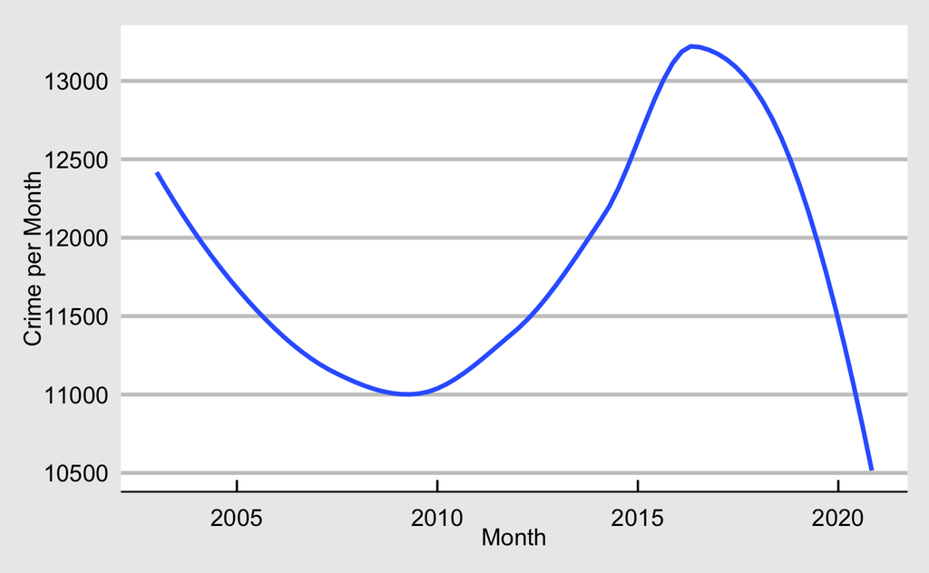

- Multivariate visualizations
- Summary tables

# Analysis

- Answers to the research questions
- Different methods considered
- Competing approaches
- Justifications

# Conclusion

- Take home message
- Limitations
- Future work?